# 텍스트분석 뉴스레터: 2023년 7월

sung won kang

2023 7 31

- 한국환경연구원 텍스트 수집 도구는 2023년 7월 30일까지 네이버 기사 데이터와 환경부 문헌 데이터를 제공한다. 아래 뉴스레터에서는 2023년 7월 1일을 기점으로 30일 이전까지 수집한 자료를 사용한다.

### A. Text 데이터

분석 대상 Text Data는 다음 두 종류의 문헌을 자료이다.

1. NAVER 환경 뉴스 : 2023년 7월 1일-2023년 7월 30일 NAVER 뉴스> ‘사회’ >‘환경’ 부문에 게시된 뉴스
2. 환경부 문건 : 2023년 7월 1일-2023년 7월 30일 환경부홈페이지에 게시된 환경부 보도자료 및 e-환경뉴스

’NAVER 환경 뉴스’는 환경정책의 수요자인 국민의 환경과 관련된 관심사를 전달하는 텍스트 자료이다. 그리고 ’환경부 문건’은 환경정책의 공급자인 환경부의 관심사를 전달하는 텍스트 자료이다. 이 두 자료의 키워드를 비교하여 환경정책 공급자의 관심사가 환경정책 수요자의 관심사에 조응하는지 여부를 점검한다.

### B. 키워드 빈도분석

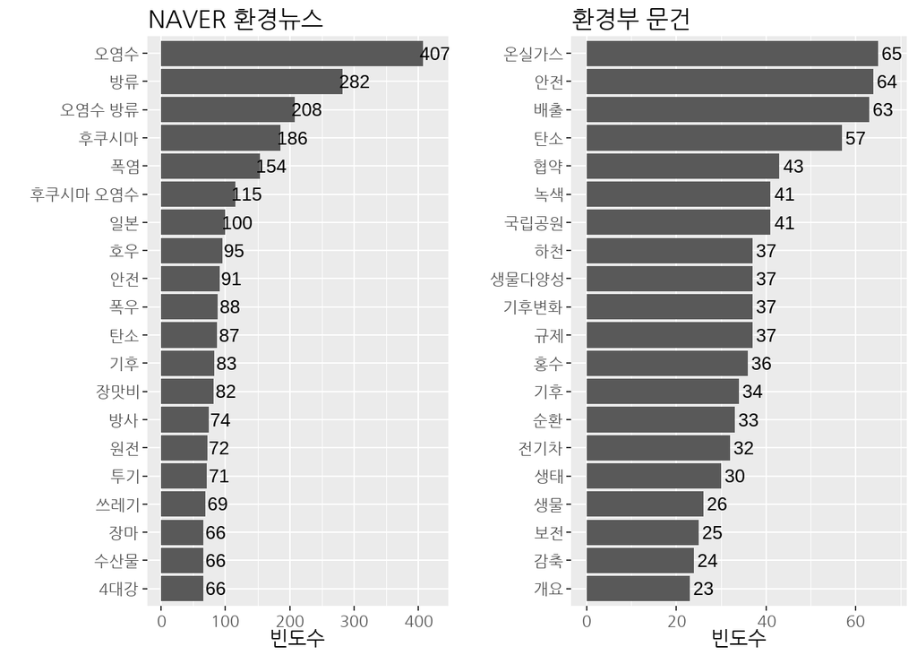

- 첫째, 네이버 환경뉴스에는 빈도수가 높은 상위 20개 키워드 중 ‘오염수’,‘후쿠시마’,‘오염수 방류’,‘방류’ 등 후쿠시마 제1원자력발전소 오염수 방류와 관련된 키워드가 발견되었지만 환경부 문건의 빈도수 상위 20개 키워드에는 이에 상응하는 키워드가 발견되지 않았다.
- 둘째, 네이버 환경뉴스에는 빈도수가 높은 상위 20개 키워드 중 ‘폭염’,‘호우’,‘폭우’,‘장맛비’,‘기후’,‘장마’ 등 장마철 이상기후 현상과 관련된 키워드가 다수 발견되었으며, 환경부 문건의 빈도수 상위 20개 키워드 중에서는 ‘안전’,‘하천’,‘’홍수’,‘기후’ 등 이상기후 현상에 대한 민간의 관심에 조응하는 키워드가 발견되었다.
- 셋째, 환경부 문건의 빈도수 상위 20개 키워드 중에는 ‘국립공원’,‘생물다양성’,‘생태’,‘생물’,‘보전’ 등 자연환경 관련 키워드, 그리고 ‘녹색’,‘규제’,‘협약’ 등 환경정책과 관련된 키워드가 포함되지만 네이버 환경뉴스에서는 이에 상응하는 키워드가 발견되지 않았다.

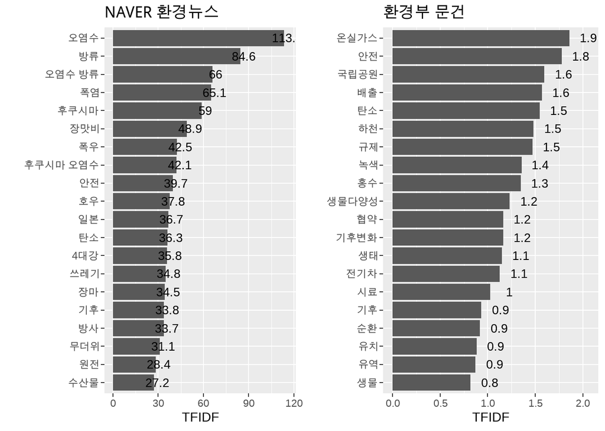

이와 같은 경향은 TF_IDF 값이 높은 20개의 키워드를 추출하여 비교하여도 확인된다. Figure 2는 TF_IDF를 기준으로 추출한 상위 20개 키워드의 TF_IDF 값을 보여준다. Figure 2에서도 확인할 수 있듯이

- ‘오염수’,‘방류’,‘후쿠시마’,’원전’과 같은 키워드는 NAVER 뉴스에서만 찾아볼 수 있다.
- ‘국립공원’,‘생물다양성’,‘생태’,‘생물’과 같이 자연환경과 관련된 키워드 및 ’규제’,‘녹색’,‘협약’ 등 환경정책 관련 문헌에서 자주 사용되는 키워드는 환경부 문건에서만 찾아 볼 수 있다.
- ‘장맛비’, ‘폭우’,‘폭염’,‘호우’,‘장마’,‘무더위’와 같은 NAVER 뉴스의 키워드와 ’하천’,‘홍수’ 와 같은 환경부 문건의 키워드는 여름철 이상기후 현상에 대한 민간의 관심과 환경부의 관심이 상호 일치함을 보여준다.

### C. 키워드 관련 뉴스

네이버 환경뉴스 키워드와 환경부 문건 키워드간의 차이의 원인을 파악하기 위해서 두 문헌에서 단순빈도가 가장 높은 10개 키워드 중 서로 상이한 키워드가 포함된 문헌의 제목들을 비교하였다.

- 네이버 환경뉴스에서 단순빈도가 높은 10개 키워드 중 환경부 문건의 단순빈도가 높은 20개 키워드에 포함되지 않은 키워드는 [오염수, 방류, 오염수 방류, 후쿠시마, 폭염, 후쿠시마 오염수, 일본, 호우, 폭우]이다.
- 환경부 문헌에서 단순빈도가 높은 10개 키워드 중 네이버 환경뉴스에서 단순빈도가 높은 20개 키워드에 포함되지 않은 키워드는 [온실가스, 배출, 협약, 녹색, 국립공원, 기후변화, 하천, 규제]이다.
1. ‘오염수’를 제목에 포함하는 기사들은 후쿠시마 제1원자력발전소 오염수 방류와 관련된 기사로 파악되었다. ’방류’,‘후쿠시마 오염수’,‘후쿠시마’, ‘오염수 방류’,’일본’을 제목에 포함하는 기사도 유사한 성향의 기사들이었다.

| Title |
| --- |
| ‘코로나 피했더니’ 피서철 시작 동해안, 이번엔 ‘日 오염수 방류’ 걱정 |
| 경기도해양수산자원硏, 꽃게·갑오징어 15만 마리 방류 |
| 후쿠시마 원전 오염수 방류 관련 정부 입장 설명하는 박구연 1차장 |
| 후쿠시마 원전 오염수 방류 관련 정부 입장 설명 |
| 후쿠시마 오염수 해양투기 저지해야 |
| 정부 “방류시 日수산물 수입할 수밖에 없단 주장은 사실 아냐” |
| 후쿠시마 오염수 해양투기 헌법소원 청구인 모집 |
| 중국 외교라인·관영매체 ‘日오염수 해양 방류 반대’ 박차 |
| 한국 정부, 후쿠시마 오염수 투기 중단 촉구를 위한 4대 종교 기자회견 |
| 일본 정부, 후쿠시마 오염수 해양 투기 철회 촉구하는 4대 종교 |

환경부 문헌에서 가장 빈도가 높은 10개 키워드 중 네이버 뉴스에서 가장 빈도가 높은 키워드 20개에 포함되지 않은 키워드는 ‘온실가스’,‘배출’,‘협약’,‘녹색’,‘국립공원’, ‘기후변화’,‘하천’,‘규제’이다. 이 중 ’온실가스’,‘배출’,‘기후변화’는 네이버 뉴스의 키워드 중 온실가스 배출과 관련된 관심을 나타내는 ’탄소’와 조응하고, ’하천’은 여름철 이상기후 현상에 대한 관심을 나타내는 ’폭우’,‘호우’와 조응한다. 반면 ’협약’,‘녹색’,‘국립공원’,’규제’는 네이버 뉴스에서 빈도가 높은 키워드 20개 중에 조응하는 키워드를 찾기 어렵다. ’2023년 7월 1일부터 7 30일까지 게시된 환경부 문헌 중 이들 키워드를 제목에 포함하는 환경부 문헌은 다음과 같다.

1. ’녹색’을 제목에 포함하는 문헌들은 모두 녹색산업과 관련된 문헌이었다.

| Title |
| --- |
| 한국-인도네시아, 녹색 기반시설 개발 협력 공동위원회 개최 |
| 라오스에도 한국 녹색산업 생태계 외연 확장 |
| 녹색산업 창업가와 기업인 교류의 장… 새싹기업(스타트업) 동창회 개최 |

2. ’규제’을 제목에 포함하는 문헌들은 기업의 환경규제 부담 완화 혹은 국제규제 대응 관련 문헌으로 파악되었다.

| Title |
| --- |
| 환경부-산업계, 국제환경규제 대응 논의 |
| 기업투자를 저해하는 환경규제 신속 개선 |
| 환경부 장관 “우리 기업 투자·경쟁력 방해하는 환경규제 과감히 혁신” |

3. ’국립공원’를 제목에 포함하는 문헌들은 하절기 국립공원 안전 관련 2건, 국립공원 해양 기후변화 연구시설 개소 관련 문헌이 1건 있었다..

| Title |
| --- |
| 거문도에 국립공원 해양 기후변화 연구시설 개소 |
| 국립공원 안전사고 예방, 샛길 출입 등 집중 단속 |
| 여름철 국립공원 물놀이, “허용된 안전한 구역에서만 하세요” |

4. ‘협약’ 을 제목에 포함하는 문헌은 존재하지 않았다.

| Title |
| --- |

### D. 정리

2023년 7월 1일-2023년 7월 30일 게시된 네이버 환경뉴스와 환경부 문헌을 비교한 결과를 요약하면 다음과 같다.

1. 네이버 기사로부터 후쿠시마 원자력발전소의 오염수 방류에 대한 국민들의 관심이 많은데 이와 관련된 환경부 문건의 비중은 낮은 것으로 파악되었다.
2. 네이버 기사와 환경부 문헌 모두 여름철 이상기후 현상인 호우 및 폭염과 관련된 키워드가 다수 발견되었다. 이는 7월 집중호우와 관련하여 민간의 관심 및 환경부의 관심이 모두 높았음을 시사한다.
3. 환경부 문헌으로부터 이 당시 환경부는 녹색산업 육성, 환경규제 부담 완화, 국립공원 안전 강화 등의 정책을 추진하였음을 알 수 있다. 이들 정책 중 녹색산업 육성은 NAVER 뉴스에서 빈도가 높았던 ‘탄소’ 관련 관심에 조응하는 정책이라고 할 수 있다. 그러나 이외의 정책은 NAVER 뉴스의 관심을 얻지 못하였다.